# Introducción al modelado de la ocupación

```r
summary(fm14 <- occu(~date + dur + I(dur^2) ~elev + I(elev^2), data=umf))
```

```
##
## Call:
## occu(formula = ~date + dur + I(dur^2) ~ elev + I(elev^2), data = umf)
##
## Occupancy (logit-scale):
##             Estimate    SE     z  P(>|z|)
## (Intercept)    1.224 0.336  3.65 2.65e-04
## elev          -0.203 0.192 -1.06 2.91e-01
## I(elev^2)     -1.179 0.282 -4.18 2.91e-05
##
## Detection (logit-scale):
##             Estimate    SE      z P(>|z|)
## (Intercept)   -0.120 0.159 -0.754  0.4507
## date          -0.235 0.116 -2.034  0.0419
## dur            0.375 0.146  2.562  0.0104
## I(dur^2)      -0.103 0.126 -0.815  0.4150
##
## AIC: 767.4348
## Number of sites: 265
## optim convergence code: 0
## optim iterations: 36
## Bootstrap iterations: 0
```

```r
summary(fm15 <- occu(~date + dur + I(dur^2) ~elev + I(elev^2) +  I(elev^3), data=umf))
```

```
##
## Call:
## occu(formula = ~date + dur + I(dur^2) ~ elev + I(elev^2) + I(elev^3),
##     data = umf)
##
## Occupancy (logit-scale):
##             Estimate    SE      z  P(>|z|)
## (Intercept)   1.2134 0.338  3.593 0.000327
## elev          0.0702 0.490  0.143 0.885935
## I(elev^2)    -1.1462 0.293 -3.906 0.000094
## I(elev^3)    -0.2049 0.340 -0.602 0.547287
##
## Detection (logit-scale):
##             Estimate    SE      z P(>|z|)
## (Intercept)  -0.1196 0.160 -0.749  0.4538
## date         -0.2369 0.116 -2.050  0.0403
## dur           0.3698 0.147  2.508  0.0121
## I(dur^2)     -0.0996 0.129 -0.772  0.4402
##
## AIC: 769.0527
## Number of sites: 265
## optim convergence code: 0
## optim iterations: 40
## Bootstrap iterations: 0
```

```r
cbind(fm13@AIC, fm14@AIC, fm15@AIC) # model 14 with elev2 best
```

```
##          [,1]     [,2]     [,3]
## [1,] 788.7067 767.4348 769.0527
```

```r
# Check effects of forest and interactions
summary(fm16 <- occu(~date + dur + I(dur^2) ~elev + I(elev^2) + forest, data=umf))
```

```
##
## Call:
## occu(formula = ~date + dur + I(dur^2) ~ elev + I(elev^2) + forest,
##     data = umf)
##
## Occupancy (logit-scale):
##             Estimate    SE     z  P(>|z|)
## (Intercept)    0.933 0.470  1.98 0.047264
## elev          -0.542 0.265 -2.04 0.040959
## I(elev^2)     -0.816 0.378 -2.16 0.030725
## forest         1.439 0.398  3.62 0.000298
##
## Detection (logit-scale):
##             Estimate    SE      z P(>|z|)
## (Intercept)  -0.1987 0.159 -1.248  0.2119
## date         -0.1867 0.113 -1.657  0.0975
## dur           0.3166 0.144  2.201  0.0277
## I(dur^2)     -0.0533 0.131 -0.406  0.6850
##
## AIC: 738.0041
## Number of sites: 265
## optim convergence code: 0
## optim iterations: 42
## Bootstrap iterations: 0
```

```r
summary(fm17 <- occu(~date + dur + I(dur^2) ~elev + I(elev^2) + forest + I(forest^2), data=umf))
```

```
##
## Call:
## occu(formula = ~date + dur + I(dur^2) ~ elev + I(elev^2) + forest +
##     I(forest^2), data = umf)
##
## Occupancy (logit-scale):
##             Estimate    SE     z  P(>|z|)
## (Intercept)    0.925 0.411  2.25 2.42e-02
## elev          -0.495 0.249 -1.99 4.64e-02
## I(elev^2)     -0.641 0.369 -1.74 8.26e-02
## forest         1.382 0.303  4.56 5.06e-06
## I(forest^2)   -0.341 0.275 -1.24 2.15e-01
##
## Detection (logit-scale):
##             Estimate    SE      z P(>|z|)
## (Intercept)  -0.1559 0.167 -0.936  0.3494
## date         -0.2009 0.115 -1.750  0.0800
## dur           0.3165 0.148  2.136  0.0327
## I(dur^2)     -0.0383 0.146 -0.263  0.7926
##
## AIC: 738.9185
## Number of sites: 265
## optim convergence code: 0
## optim iterations: 47
## Bootstrap iterations: 0
```

```r
summary(fm18 <- occu(~date + dur +I(dur^2) ~elev+I(elev^2)+forest+I(forest^2)+elev:forest, data=umf))
```

```
##
## Call:
## occu(formula = ~date + dur + I(dur^2) ~ elev + I(elev^2) + forest +
##     I(forest^2) + elev:forest, data = umf)
##
## Occupancy (logit-scale):
##             Estimate    SE     z  P(>|z|)
## (Intercept)    0.867 0.399  2.17 2.97e-02
## elev          -0.477 0.246 -1.94 5.28e-02
## I(elev^2)     -0.633 0.364 -1.74 8.20e-02
## forest         1.435 0.299  4.81 1.54e-06
## I(forest^2)   -0.419 0.250 -1.67 9.43e-02
## elev:forest    0.309 0.266  1.16 2.44e-01
##
## Detection (logit-scale):
##             Estimate    SE      z P(>|z|)
## (Intercept)  -0.1260 0.164 -0.769  0.4421
## date         -0.2063 0.115 -1.798  0.0721
## dur           0.3061 0.149  2.058  0.0396
## I(dur^2)     -0.0436 0.143 -0.306  0.7599
##
## AIC: 739.5644
## Number of sites: 265
## optim convergence code: 0
## optim iterations: 46
## Bootstrap iterations: 0
```

```r
summary(fm19 <- occu(~date+dur+I(dur^2) ~elev+I(elev^2)+forest+I(forest^2)+elev:forest+elev:I(forest^2), data=umf))
```

```
##
## Call:
## occu(formula = ~date + dur + I(dur^2) ~ elev + I(elev^2) + forest +
##     I(forest^2) + elev:forest + elev:I(forest^2), data = umf)
##
## Occupancy (logit-scale):
##                  Estimate    SE      z  P(>|z|)
## (Intercept)         0.853 0.399  2.140 3.24e-02
## elev               -0.680 0.330 -2.060 3.94e-02
## I(elev^2)          -0.653 0.372 -1.757 7.89e-02
## forest              1.383 0.295  4.696 2.65e-06
## I(forest^2)        -0.325 0.285 -1.139 2.55e-01
## elev:forest         0.185 0.280  0.662 5.08e-01
## elev:I(forest^2)    0.257 0.272  0.944 3.45e-01
##
## Detection (logit-scale):
##             Estimate    SE      z P(>|z|)
## (Intercept)  -0.1396 0.167 -0.836  0.4030
## date         -0.2017 0.115 -1.759  0.0786
## dur           0.3106 0.148  2.096  0.0361
## I(dur^2)     -0.0366 0.145 -0.253  0.8006
##
## AIC: 740.6342
## Number of sites: 265
## optim convergence code: 0
## optim iterations: 52
## Bootstrap iterations: 0
```

```r
summary(fm20 <- occu(~date+dur+I(dur^2) ~elev+I(elev^2)+forest+I(forest^2)+elev:forest+elev:I(forest^2)+I(elev^2):forest, data=umf))
```

```
##
## Call:
## occu(formula = ~date + dur + I(dur^2) ~ elev + I(elev^2) + forest +
##     I(forest^2) + elev:forest + elev:I(forest^2) + I(elev^2):forest,
##     data = umf)
##
## Occupancy (logit-scale):
##                  Estimate    SE      z P(>|z|)
## (Intercept)         0.778 0.346  2.248  0.0246
## elev               -0.771 0.362 -2.130  0.0332
## I(elev^2)          -0.544 0.388 -1.402  0.1610
## forest              0.431 0.436  0.987  0.3235
## I(forest^2)        -0.209 0.254 -0.823  0.4103
## elev:forest         0.197 0.371  0.532  0.5947
## elev:I(forest^2)    0.347 0.318  1.091  0.2753
## I(elev^2):forest    1.174 0.468  2.509  0.0121
##
## Detection (logit-scale):
##             Estimate    SE      z P(>|z|)
## (Intercept)  -0.0985 0.160 -0.616  0.5379
## date         -0.2135 0.116 -1.845  0.0651
## dur           0.3242 0.147  2.205  0.0275
## I(dur^2)     -0.0192 0.131 -0.147  0.8830
##
## AIC: 735.5701
## Number of sites: 265
## optim convergence code: 0
## optim iterations: 48
## Bootstrap iterations: 0
```

```r
summary(fm21 <- occu(~date+dur+I(dur^2) ~elev+I(elev^2)+forest+I(forest^2)+elev:forest+elev:I(forest^2)+I(elev^2):forest+ I(elev^2):I(forest^2), data=umf))
```

```
##
## Call:
## occu(formula = ~date + dur + I(dur^2) ~ elev + I(elev^2) + forest +
##     I(forest^2) + elev:forest + elev:I(forest^2) + I(elev^2):forest +
##     I(elev^2):I(forest^2), data = umf)
##
## Occupancy (logit-scale):
##                       Estimate    SE      z P(>|z|)
## (Intercept)              0.953 0.390  2.441  0.0146
## elev                    -0.817 0.359 -2.278  0.0227
## I(elev^2)               -0.907 0.488 -1.858  0.0632
## forest                   0.642 0.465  1.380  0.1675
## I(forest^2)             -0.488 0.338 -1.442  0.1494
## elev:forest              0.221 0.345  0.642  0.5209
## elev:I(forest^2)         0.435 0.332  1.311  0.1899
## I(elev^2):forest         0.991 0.483  2.053  0.0401
## I(elev^2):I(forest^2)    0.537 0.449  1.196  0.2319
##
## Detection (logit-scale):
##             Estimate    SE      z P(>|z|)
## (Intercept)  -0.0931 0.159 -0.587  0.5572
## date         -0.2174 0.115 -1.883  0.0597
## dur           0.3192 0.147  2.165  0.0304
## I(dur^2)     -0.0213 0.132 -0.161  0.8721
##
## AIC: 736.1344
## Number of sites: 265
## optim convergence code: 0
## optim iterations: 53
## Bootstrap iterations: 0
```

```r
cbind(fm16@AIC, fm17@AIC, fm18@AIC, fm19@AIC, fm20@AIC) # fm20 es el mejor
```

```
##          [,1]     [,2]     [,3]     [,4]     [,5]
## [1,] 738.0041 738.9185 739.5644 740.6342 735.5701
```

```r
# -----------------------------
# OJO: modelo fm16
# para ver coeficientes
fm16[1]@estimates[1] #intercepto
```

```
## (Intercept)
##   0.9332777
```

```r
fm16[1]@estimates[2] #elev
```

```
##       elev
## -0.5424226
```

```r
fm16[1]@estimates[3] #forest
```

```
## I(elev^2)
## -0.816405
```

```r
# para linearizar psi y p
# para linearizar psi y p en modelos sencillos
fm1
```

```
##
## Call:
## occu(formula = ~1 ~ 1, data = umf)
##
## Occupancy:
##  Estimate    SE     z P(>|z|)
##     0.168 0.173 0.974    0.33
##
## Detection:
##  Estimate    SE     z P(>|z|)
##    -0.144 0.136 -1.06   0.291
##
## AIC: 805.9027
```

```r
backTransform(fm1, "state") # ocupación
```

```
## Backtransformed linear combination(s) of Occupancy estimate(s)
##
##  Estimate     SE LinComb (Intercept)
##     0.542 0.0429   0.168           1
##
## Transformation: logistic
```

```r
backTransform(fm1, "det") # detección
```

```
## Backtransformed linear combination(s) of Detection estimate(s)
##
##  Estimate     SE LinComb (Intercept)
##     0.464 0.0338  -0.144           1
##
## Transformation: logistic
```

```r
# para linearizar psi y p en modelos más complejos
fm16
```

```
##
## Call:
## occu(formula = ~date + dur + I(dur^2) ~ elev + I(elev^2) + forest,
##     data = umf)
##
## Occupancy:
##             Estimate    SE     z  P(>|z|)
## (Intercept)    0.933 0.470  1.98 0.047264
## elev          -0.542 0.265 -2.04 0.040959
## I(elev^2)     -0.816 0.378 -2.16 0.030725
## forest         1.439 0.398  3.62 0.000298
##
## Detection:
##             Estimate    SE      z P(>|z|)
## (Intercept)  -0.1987 0.159 -1.248  0.2119
## date         -0.1867 0.113 -1.657  0.0975
## dur           0.3166 0.144  2.201  0.0277
## I(dur^2)     -0.0533 0.131 -0.406  0.6850
##
## AIC: 738.0041
```

```r
backTransform(linearComb(fm16, coefficients=c(1,0,0,0), type="state"))
```

```
## Backtransformed linear combination(s) of Occupancy estimate(s)
##
##  Estimate     SE LinComb (Intercept) elev I(elev^2) forest
##     0.718 0.0953   0.933           1    0         0      0
##
## Transformation: logistic
```

```r
backTransform(linearComb(fm16, coefficients=c(1,0,0,0), type="det"))
```

```
## Backtransformed linear combination(s) of Detection estimate(s)
##
##  Estimate     SE LinComb (Intercept) date dur I(dur^2)
##      0.45 0.0394  -0.199           1    0   0        0
##
## Transformation: logistic
```

# —————————————-

## PASO 5: para graficar

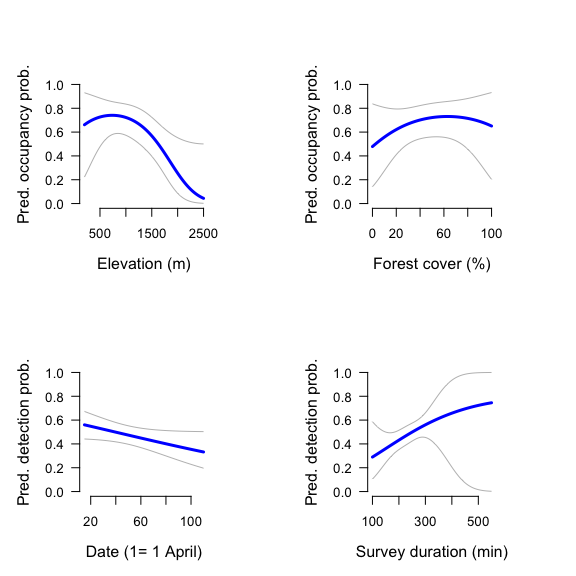

```r
# se crean primero nuevas covariables estandarizadas
orig.elev <- seq(200, 2500,,100)
orig.forest <- seq(0, 100,,100)
orig.date <- seq(15, 110,,100)
orig.duration <- seq(100, 550,,100)
# estandarizadas
ep <- (orig.elev - means[1]) / sds[1]
fp <- (orig.forest - means[2]) / sds[2]
dp <- (orig.date - means[3]) / sds[3]
durp <- (orig.duration - means[4]) / sds[4]

# predicción por covariable separada
newData <- data.frame(elev=ep, forest=0)
pred.occ.elev <- predict(fm20, type="state", newdata=newData, appendData=TRUE)

newData <- data.frame(elev=0, forest=fp)
pred.occ.forest <- predict(fm20, type="state", newdata=newData, appendData=TRUE)

newData <- data.frame(date=dp, dur=0)
pred.det.date <- predict(fm20, type="det", newdata=newData, appendData=TRUE)

newData <- data.frame(date=0, dur=durp)
pred.det.dur <- predict(fm20, type="det", newdata=newData, appendData=TRUE)

# gráficos
par(mfrow=c(2,2), mar=c(5,5,5,5), cex.lab=1.2)

plot(pred.occ.elev[[1]] ~ orig.elev, type="l", lwd=3, col="blue", ylim=c(0,1), las=1, ylab="Pred. occupancy prob.", xlab="Elevation (m)", frame=F)
matlines(orig.elev, pred.occ.elev[,3:4], lty=1, lwd=1, col="grey")

plot(pred.occ.forest[[1]] ~ orig.forest, type="l", lwd=3, col="blue", ylim=c(0,1), las=1, ylab="Pred. occupancy prob.", xlab="Forest cover (%)", frame=F)
matlines(orig.forest, pred.occ.forest[,3:4], lty=1, lwd=1, col="grey")

plot(pred.det.date[[1]] ~ orig.date, type="l", lwd=3, col="blue", ylim=c(0,1), las=1, ylab="Pred. detection prob.", xlab="Date (1= 1 April)", frame=F)
matlines(orig.date, pred.det.date[,3:4], lty=1, lwd=1, col="grey")

plot(pred.det.dur[[1]] ~ orig.duration, type="l", lwd=3, col="blue", ylim=c(0,1), las=1, ylab="Pred. detection prob.", xlab="Survey duration (min)", frame=F)
matlines(orig.duration, pred.det.dur[,3:4], lty=1, lwd=1, col="grey")
```

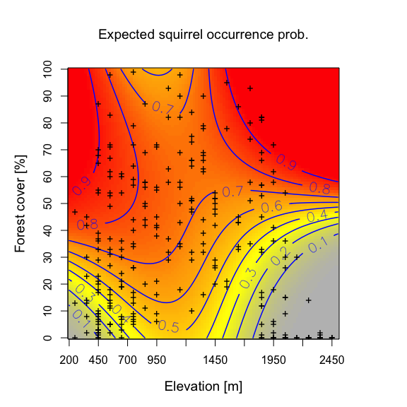

```r
# predicción por covariables simultaneas
# Ocupación ~ (forest, elevation) y detección ~ (survey duration, date)
pred.matrix1 <- pred.matrix2 <- array(NA, dim=c(100,100))
for(i in 1:100){
  for(j in 1:100){
    newData1 <- data.frame(elev=ep[i], forest=fp[j])       # para ocupación
    pred <- predict(fm20, type="state", newdata=newData1)
    pred.matrix1[i, j] <- pred$Predicted
    newData2 <- data.frame(dur=durp[i], date=dp[j])        # para detección
    pred <- predict(fm20, type="det", newdata=newData2)
    pred.matrix2[i, j] <- pred$Predicted
  }
}

par(mfrow=c(1,1), mar=c(5,5,5,5), cex.lab=1.2)
mapPalette <- colorRampPalette(c("grey", "yellow", "orange", "red"))
image(x=orig.elev, y=orig.forest, z=pred.matrix1, col=mapPalette(100), axes=FALSE, xlab = "Elevation [m]", ylab="Forest cover [%]")
contour(x=orig.elev, y=orig.forest, z=pred.matrix1, add=TRUE, lwd=1.5, col="blue", labcex=1.3)
axis(1, at=seq(min(orig.elev), max(orig.elev), by=250))
axis(2, at=seq(0,100, by=10))
box()
title(main="Expected squirrel occurrence prob.", font.main=1)
points(data$ele, data$forest, pch="+", cex=1)
```

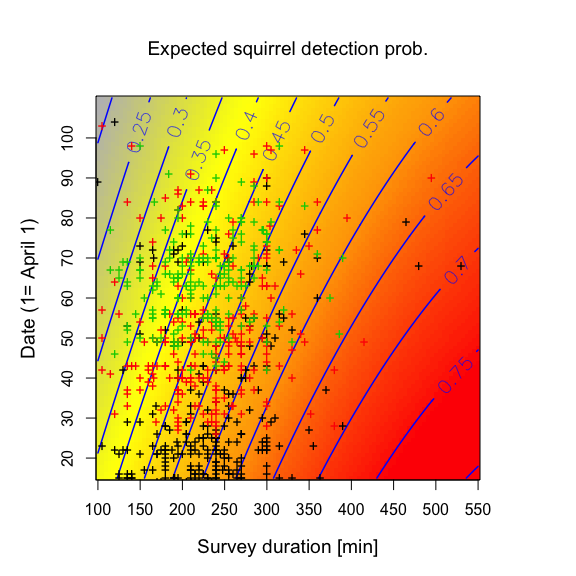

```r
image(x=orig.duration, y=orig.date, z=pred.matrix2, col=mapPalette(100), axes=FALSE, xlab="Survey duration [min]", ylab="Date (1= April 1)")
contour(x=orig.duration, y=orig.date, z=pred.matrix2, add=TRUE, lwd=1.5, col="blue", labcex=1.3)
axis(1, at=seq(min(orig.duration), max(orig.duration), by=50))
axis(2, at=seq(0,100, by=10))
box()
title(main="Expected squirrel detection prob.", font.main=1)
matpoints(as.matrix(data[, 13:15]), as.matrix(data[, 10:12]), pch="+", cex=1)
```

# ——————————————

## PASO 6: para mapear las ocupación

```r
CH <- read.csv("Switzerland.csv", header=T)

# genera predicciones de la ocupación para cada cuadrante de 1 km2
newData <- data.frame(elev=(CH$elevation-means[1])/sds[1], forest=(CH$forest-means[2])/sds[2])
predCH <- predict(fm20, type="state", newdata=newData)
```

[output not shown]

```r
# para convertir a raster
PARAM <- data.frame(x=CH$x, y=CH$y, z=predCH$Predicted)
r1 <- rasterFromXYZ(PARAM)

# Máscara de cuadrantes con elevaciones mayores a 2250 m
elev <- rasterFromXYZ(cbind(CH$x, CH$y, CH$elevation))
elev[elev > 2250] <- NA
r1 <- mask(r1, elev)
```

[output not shown]

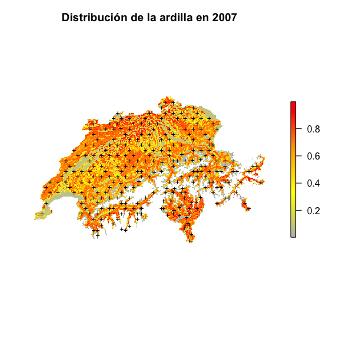

```r
# Mapa de distribución ocupación
par(mfrow=c(1,1), mar=c(3,3,3,3))
mapPalette <- colorRampPalette(c("grey","yellow","orange","red"))
plot(r1, col=mapPalette(100), axes=F, box=F, main="Distribución de la ardilla en 2007")
points(data$coordx, data$coordy, pch="+", cex=0.8)
```

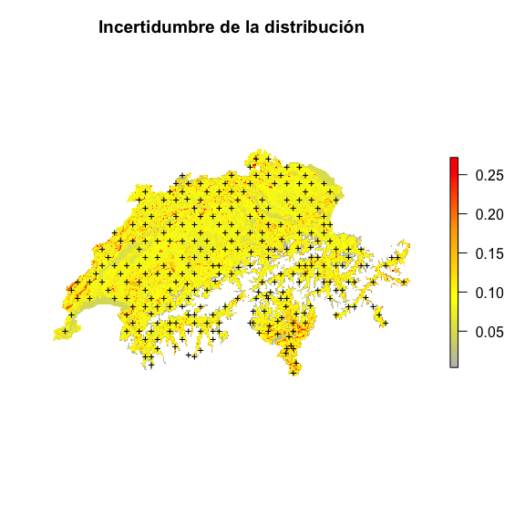

```r
# Mapa distribución de incertidumbre
r2 <- rasterFromXYZ(data.frame(x=CH$x, y=CH$y, z=predCH$SE))
r2 <- mask(r2, elev)
plot(r2, col=mapPalette(100), axes=F, box=F, main="Incertidumbre de la distribución")
points(data$coordx, data$coordy, pch="+", cex=0.8)
```

# PASO 7:Estimación del área de ocurrencia de la ardilla durante el 2007

```r
# Superficie estimada:
sum(predCH$Predicted)
```

```
## [1] 17354.57
```

```r
sum(predCH$Predicted[CH$elevation < 1000]) # predicción a menos de 1000m
```

```
## [1] 10117.21
```

# ——————————————

# Conclusiones

El análisis de ocupación de la ardilla en Suiza sugiere que esta especie ocupa 17,354 km2 lo cual corresponde al 41% de la superficie de este país. Las principales variables a la ocupación fueron la elevación (altitud) y la cobvertura del bosque.

Específicamente, a mayor altitud disminuye la ocupación; mientras que a coberturas mayores del 40% aumenta la ocupación. Por otro lado, los análisis sugieren que la probabilidad de detección disminuye conforme pasan más días desde el inicio de muestreo, y aumenta conforme la duración de cada muestreo se incrementa.

Finalmente, es importante interpretar estos resultados en términos de la temporalidad. Los datos aquí analizados, aunque muy extensos, solo corresponden al muestreo de un solo año (2007). En este sentido, siempre es deseable y recomendable tener más años de muestreo para conocer variaciones en la ocupación, y definir si las mismas variables cada año afectan de similar manera la ocupación y la detección. Para estos casos, son convenientes los modelos de ocupación “*multi-seasons*”.

# ——————————————

# El presente documento fue generado con la herramienta R Markdown